# Discussion 6

# Present Group Members

Please **write the names of your group members** here.

> Present Group Member(s):

> Absent Group Member(s):

# Preliminaries

- This file should be in `STAT240/discussion/ds06`.
- Please also download `Messi_Through_Oct112024_FBRef.csv` to `STAT240/data`.
- This assignment should be completed in your **assigned Canvas groups**. Only one person has to submit on behalf of the group. You may submit whatever you have at the end of discussion section for full credit.

# Problem 1

The following dataset contains information on all the games Lionel Messi has played in the 2024 season, sourced from [FBRef.com](https://fbref.com/en/players/d70ce98e/matchlogs/2024/Lionel-Messi-Match-Logs).

```r
messi_original = read_csv("../../data/Messi_Through_Oct112024_FBRef.csv")
```

Each row is a single game. The `Gls` column indicates how many goals Messi scored in that game, and `Ast` indicates how many assists Messi provided in that game. (An assist is a pass that leads to a goal.)

**Create and save a new dataframe** called whatever you want, by executing the following steps, starting from `messi_original`,

- Create a new column called `points`, calculated as `Gls + Ast`. (You can think of this as how many goals Messi was involved in during that game - a term borrowed from hockey.)
- Summarize to obtain one row for each unique value of `points`, with a new column `n` indicating in how many games Messi scored that exact value of `Points`. *Check: Your dataframe should indicate that Messi has scored 0 points 10 times, 1 point 8 times… and one time only he scored 6 points!*
- Create a new column called `percent`, which indicates in what percent of games Messi scored that exact value of points. *(Hint: The total number of games played can be figured out exclusively from the `n` column!)*

```r
# Write your code here!
messi_summary = messi_original %>%
  mutate(points = Gls + Ast) %>%
  count(points) %>%
  mutate(percent = n/sum(n))

messi_summary
```

```
## # A tibble: 6 × 3
##   points     n percent
##    <dbl> <int>   <dbl>
## 1      0    10  0.385
## 2      1     8  0.308
## 3      2     3  0.115
## 4      3     3  0.115
## 5      4     1  0.0385
## 6      6     1  0.0385
```

# Problem 2

`points` and `percent` from the dataframe above form a **probability distribution**.

Is it a **discrete** probability distribution or a **continuous** one? Briefly explain why.

> It is a discrete probability distribution; the values of `points`, while numeric, can only take on a specific, countable set of whole number values.

# Problem 3

Using your dataframe from problem 1, what is the **average number of points** Messi has scored in games in 2024?

```r
mean = sum(messi_summary$points * messi_summary$percent)

mean
```

```
## [1] 1.269231
```

# Problem 4

**Plot** the probability distribution, with a vertical bar for each value of `points`, the height of which represents `percent`.

Incorporate the following customizations:

- Adjust the X axis so that the ticks and labels indicate every whole number 0 through 6.
- Add a **red, vertical, dashed** line at the mean you calculated in problem 3.
- Make at least one other fun visual improvement that you think makes the graph look better - adjust the colors, add a theme, et cetera!

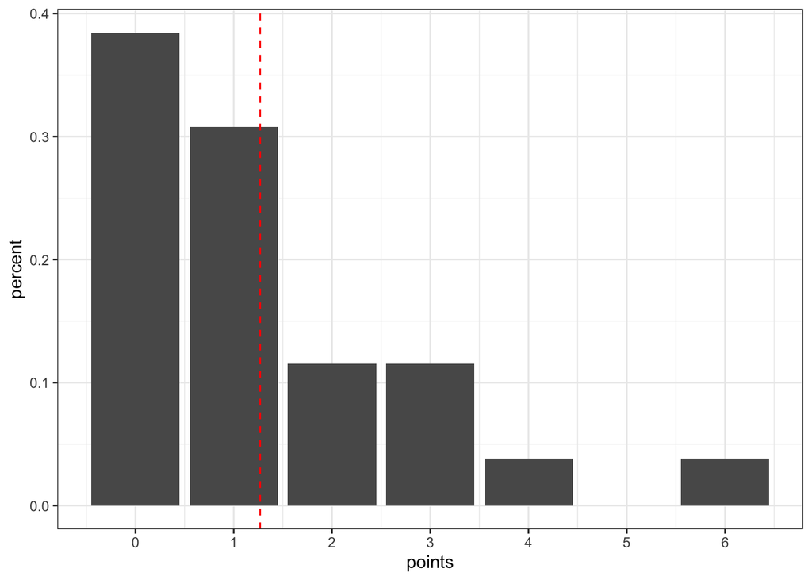

```r
ggplot(messi_summary, aes(points, percent)) +
  geom_col() +
  geom_vline(xintercept = mean, color = "red", linetype = "dashed") +
  scale_x_continuous(breaks = 0:6) +
  theme_bw()
```

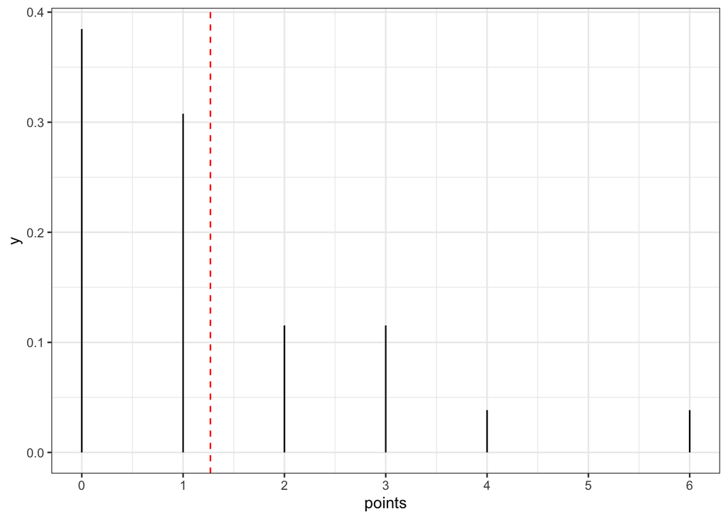

```r
# You can also do this with geom_segment
ggplot(messi_summary, aes(x = points, xend = points, y = 0, yend = percent)) +
  geom_segment() +
    geom_vline(xintercept = mean, color = "red", linetype = "dashed") +
  scale_x_continuous(breaks = 0:6) +
  theme_bw()
```

# Problem 5

For context, Messi made his professional soccer debut in 2004 at the age of 17, and is now 37 and still playing.

The average you calculated in problem 3 and graphed in problem 4 should have been about 1.27.

**Is it valid to say that in a random game from Messi’s entire career, we would expect him to score about 1.27 points?** If not, why not?

> No, it is not valid. We cannot extrapolate the 1.27 value from 2024 to his whole career, as he may have played differently/in a harder league/been more fit when he was younger/ any number of reasons that mean the 2024 season is not representative of his whole career.

# Problem 6

Using your dataframe from problem 1, what is the **variance** and **standard deviaton** of the number of points Messi has scored in 2024?

```r
sum((messi_summary$points - mean)^2 * messi_summary$percent)
```

```
## [1] 2.196746
```

```r
# Neat little trick; the "with" command prevents you from having to write "messi_summary$" every time
with(messi_summary,
     sum((points-mean)^2*percent))
```

```
## [1] 2.196746
```

# Problem 7

In what percent of 2024 games did Messi score multiple points?

*This would be easy to do by hand; but try to do it by code using your dataframe from problem 1!*

```r
messi_summary %>%
  filter(points > 1) %>%
  summarize(p = sum(percent))
```

```
## # A tibble: 1 × 1
##       p
##   <dbl>
## 1 0.308
```

# Problem 8

The percentage you calculated above should be 30.8%. **a)** Is it valid to say that in a randomly selected game from Messi’s entire career, there is a 30.8% chance he scored multiple points?

> No. This information is just from the 2024 sample.

Is it valid to say that in a randomly selected game Messi played in 2024, there is a 30.8% chance he scored multiple points?

> Yes - 30.8% comes from 2024 games, so that random process would result in this probability distribution.